# Visualizing 3D Objects with RMINC

As of RMINC 1.3 we’ve begun to support visualizing 3D volumes with R. This document is designed to showcase a few of these features.

```r
#Load in our libraries
library(RMINC)
library(rgl)
```

Let pull in a demonstration object file. The file format currently supported by RMINC is the BIC-MNI text obj format, documented [on their github](https://github.com/BIC-MNI/bicpl/Documentation). This file format is used by CIVET, amongst other tools, to store brain surfaces. The figures produces are interactive and can be rotated and magnified with the mouse.

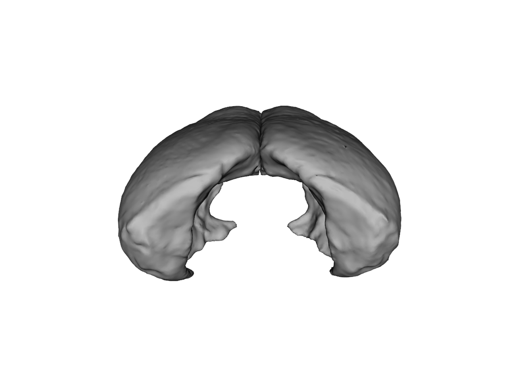

```r
mouse_cortex <-
  read_obj("/axiom2/projects/software/cortical-thickness/MWM/c57bl6_laplacian_grid_full_surface_simplified.obj")

plot(mouse_cortex)
```

In addition to creating surfaces, it is possible to add statistics maps, thresholded and with colour legends

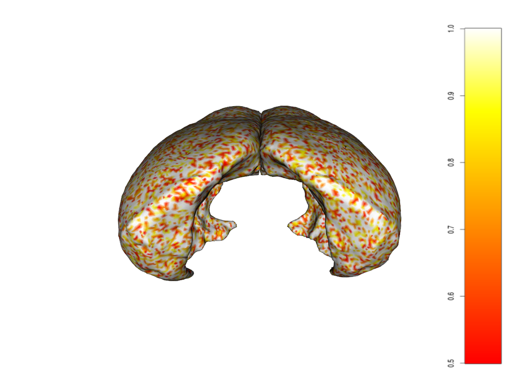

```r
demo_stats <- #Generate some random uniform vertex data
  runif(ncol(mouse_cortex$vertex_matrix))

plot(mouse_cortex, demo_stats, colour_range = c(.5,1))
```

It is also possible to identify vertices from a figure

```r
selected_vertices <- vertexSelect(multiples = TRUE)
```

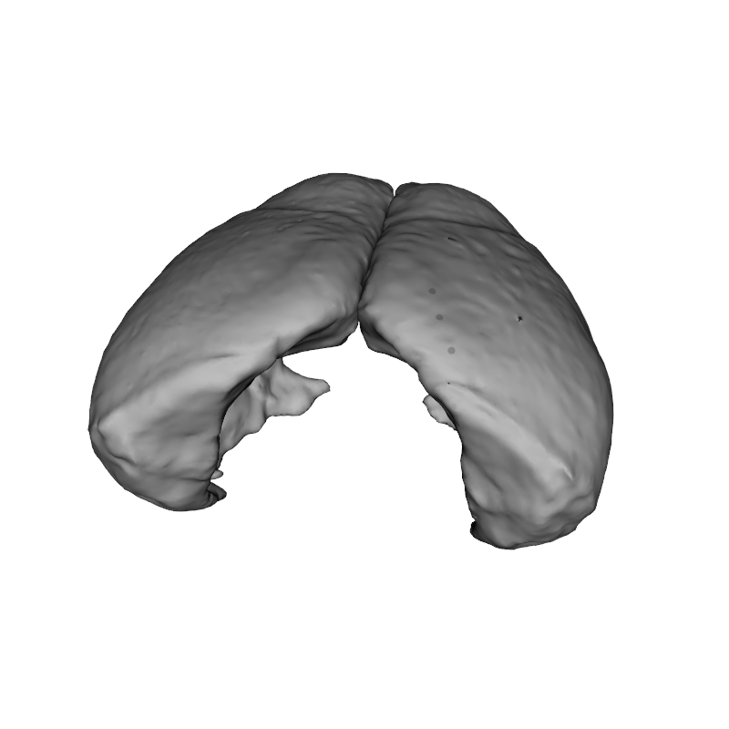

To disable the indicator spheres, simply run `vertexSelect` with `indicate = FALSE`. To remove the spheres after you’ve verified the are correct, run `rgl::pop3d()`, only do this if you have not added elements to the rgl scene after the spheres, otherwise you will need to look up their id’s with `rgl::ids()`. See `?vertexSelect` for details.

Once you’ve identified your vertices of interest, you can find those vertices within the statistic map

```r
vertexLookup(mouse_cortex, selected_vertices, demo_stats)
```

```
## [1] 0.92067323 0.04072155 0.75905397
```